# Estatística Multivariada - aula 0

Marcos Vital

10 de agosto de 2017

### Aula preliminar da disciplina Estatística Multivariada, do PPG-DIBICT UFAL

Por [Marcos Vital](https://medium.com/@marcosvital), do [LEQ-UFAL](https://www.facebook.com/leq.ufal/)

Este documento é o primeiro de uma série de scripts que foram construídos ao longo da disciplina de Estatística Multivariada ministrada por mim no Programa de Pós-graduação em Diversidade Biológica e Conservação dos Trópicos da UFAL. Os scripts foram desenvolvidos durante as aulas e, posteriormente, editados para pequenas melhorias, correções e comentários. Apesar do objetivo central é servir como material de apoio para os estudantes que cursaram a disciplina, a ideia também era documentar as atividades práticas de tal forma que eles possam ser úteis para outras pessoas.

Como está é uma aula introdutória anterior ao conteúdo sobre Multivariada, considero-a como uma “aula 0”. ;)

Este primeiro e pequeno script foi construído para revisarmos rapidamente alguns dos elementos básicos do R, uma vez que a turma era bastante heterogênea em termos de experiência prévia com a linguagem. O principal objetivo aqui foi rever a estrutura de um data-frame no R e criar alguns gráficos simples.

### Carregando e conferindo os dados

Aqui vamos carregar um conjunto de dados “nativo” do próprio R, usando a função `data`:

```r
data(iris)  #carrega o conjunto de dados iris
```

Você pode mostrar os dados no console do R toscamente, assim:

```r
iris        #mostra todo o objeto no console (ruim se o objeto for grande!)
```

```
##     Sepal.Length Sepal.Width Petal.Length Petal.Width    Species
## 1            5.1         3.5          1.4         0.2     setosa
## 2            4.9         3.0          1.4         0.2     setosa
## 3            4.7         3.2          1.3         0.2     setosa
## 4            4.6         3.1          1.5         0.2     setosa
## 5            5.0         3.6          1.4         0.2     setosa
## 6            5.4         3.9          1.7         0.4     setosa
## 7            4.6         3.4          1.4         0.3     setosa
## 8            5.0         3.4          1.5         0.2     setosa
## 9            4.4         2.9          1.4         0.2     setosa
## 10           4.9         3.1          1.5         0.1     setosa
## 11           5.4         3.7          1.5         0.2     setosa
## 12           4.8         3.4          1.6         0.2     setosa
## 13           4.8         3.0          1.4         0.1     setosa
## 14           4.3         3.0          1.1         0.1     setosa
```

[output cut: 136 more lines]

Mas provavelmente vai ser melhor usar uma das funções a seguir:

```r
summary(iris)   #resume o objeto
```

```
##   Sepal.Length    Sepal.Width     Petal.Length    Petal.Width
##  Min.   :4.300   Min.   :2.000   Min.   :1.000   Min.   :0.100
##  1st Qu.:5.100   1st Qu.:2.800   1st Qu.:1.600   1st Qu.:0.300
##  Median :5.800   Median :3.000   Median :4.350   Median :1.300
##  Mean   :5.843   Mean   :3.057   Mean   :3.758   Mean   :1.199
##  3rd Qu.:6.400   3rd Qu.:3.300   3rd Qu.:5.100   3rd Qu.:1.800
##  Max.   :7.900   Max.   :4.400   Max.   :6.900   Max.   :2.500
##        Species
##  setosa    :50
##  versicolor:50
##  virginica :50
##
##
##
```

```r
str(iris)       #Mostra a estrutura do objeto (alternativa ao summary)
```

```
## 'data.frame':    150 obs. of  5 variables:
##  $ Sepal.Length: num  5.1 4.9 4.7 4.6 5 5.4 4.6 5 4.4 4.9 ...
##  $ Sepal.Width : num  3.5 3 3.2 3.1 3.6 3.9 3.4 3.4 2.9 3.1 ...
##  $ Petal.Length: num  1.4 1.4 1.3 1.5 1.4 1.7 1.4 1.5 1.4 1.5 ...
##  $ Petal.Width : num  0.2 0.2 0.2 0.2 0.2 0.4 0.3 0.2 0.2 0.1 ...
##  $ Species     : Factor w/ 3 levels "setosa","versicolor",..: 1 1 1 1 1 1 1 1 1 1 ...
```

### Entendendo um data-frame no R

Os dados que usamos no R (como os do exemplo acima), são tipicamente armazenados em um objeto da categoria `data.frame`. Aprender como este tipo de objeto funciona é fundamental para se usar bem o R.

**O uso do $ para acessar uma coluna qualquer:**

```r
#Essa é fácil:
iris$Sepal.Width  #mostra apenas a coluna indicada
```

```
##   [1] 3.5 3.0 3.2 3.1 3.6 3.9 3.4 3.4 2.9 3.1 3.7 3.4 3.0 3.0 4.0 4.4 3.9
##  [18] 3.5 3.8 3.8 3.4 3.7 3.6 3.3 3.4 3.0 3.4 3.5 3.4 3.2 3.1 3.4 4.1 4.2
##  [35] 3.1 3.2 3.5 3.6 3.0 3.4 3.5 2.3 3.2 3.5 3.8 3.0 3.8 3.2 3.7 3.3 3.2
##  [52] 3.2 3.1 2.3 2.8 2.8 3.3 2.4 2.9 2.7 2.0 3.0 2.2 2.9 2.9 3.1 3.0 2.7
##  [69] 2.2 2.5 3.2 2.8 2.5 2.8 2.9 3.0 2.8 3.0 2.9 2.6 2.4 2.4 2.7 2.7 3.0
##  [86] 3.4 3.1 2.3 3.0 2.5 2.6 3.0 2.6 2.3 2.7 3.0 2.9 2.9 2.5 2.8 3.3 2.7
## [103] 3.0 2.9 3.0 3.0 2.5 2.9 2.5 3.6 3.2 2.7 3.0 2.5 2.8 3.2 3.0 3.8 2.6
## [120] 2.2 3.2 2.8 2.8 2.7 3.3 3.2 2.8 3.0 2.8 3.0 2.8 3.8 2.8 2.8 2.6 3.0
## [137] 3.4 3.1 3.0 3.1 3.1 3.1 2.7 3.2 3.3 3.0 2.5 3.0 3.4 3.0
```

**Usando colchetes para se acessar linhas ou colunas:**

A forma geral é fácil de entender: `objeto[linhas, colunas]`. O melhor é aprender com exemplos, olhe aqui:

```r
iris [ , 2]                    #mostra apenas a coluna 2
```

```
##   [1] 3.5 3.0 3.2 3.1 3.6 3.9 3.4 3.4 2.9 3.1 3.7 3.4 3.0 3.0 4.0 4.4 3.9
##  [18] 3.5 3.8 3.8 3.4 3.7 3.6 3.3 3.4 3.0 3.4 3.5 3.4 3.2 3.1 3.4 4.1 4.2
##  [35] 3.1 3.2 3.5 3.6 3.0 3.4 3.5 2.3 3.2 3.5 3.8 3.0 3.8 3.2 3.7 3.3 3.2
##  [52] 3.2 3.1 2.3 2.8 2.8 3.3 2.4 2.9 2.7 2.0 3.0 2.2 2.9 2.9 3.1 3.0 2.7
##  [69] 2.2 2.5 3.2 2.8 2.5 2.8 2.9 3.0 2.8 3.0 2.9 2.6 2.4 2.4 2.7 2.7 3.0
##  [86] 3.4 3.1 2.3 3.0 2.5 2.6 3.0 2.6 2.3 2.7 3.0 2.9 2.9 2.5 2.8 3.3 2.7
## [103] 3.0 2.9 3.0 3.0 2.5 2.9 2.5 3.6 3.2 2.7 3.0 2.5 2.8 3.2 3.0 3.8 2.6
## [120] 2.2 3.2 2.8 2.8 2.7 3.3 3.2 2.8 3.0 2.8 3.0 2.8 3.8 2.8 2.8 2.6 3.0
## [137] 3.4 3.1 3.0 3.1 3.1 3.1 2.7 3.2 3.3 3.0 2.5 3.0 3.4 3.0
```

```r
iris [4, ]                     #mostra apenas a linha 4
```

```
##   Sepal.Length Sepal.Width Petal.Length Petal.Width Species
## 4          4.6         3.1          1.5         0.2  setosa
```

```r
iris[1:10, ]                   #mostra linhas 1 a 10
```

```
##    Sepal.Length Sepal.Width Petal.Length Petal.Width Species
## 1           5.1         3.5          1.4         0.2  setosa
## 2           4.9         3.0          1.4         0.2  setosa
## 3           4.7         3.2          1.3         0.2  setosa
## 4           4.6         3.1          1.5         0.2  setosa
## 5           5.0         3.6          1.4         0.2  setosa
## 6           5.4         3.9          1.7         0.4  setosa
## 7           4.6         3.4          1.4         0.3  setosa
## 8           5.0         3.4          1.5         0.2  setosa
## 9           4.4         2.9          1.4         0.2  setosa
## 10          4.9         3.1          1.5         0.1  setosa
```

```r
iris[ , 3:4]                   #mostra colunas 3 a 4
```

```
##     Petal.Length Petal.Width
## 1            1.4         0.2
## 2            1.4         0.2
## 3            1.3         0.2
## 4            1.5         0.2
## 5            1.4         0.2
## 6            1.7         0.4
## 7            1.4         0.3
## 8            1.5         0.2
## 9            1.4         0.2
## 10           1.5         0.1
## 11           1.5         0.2
## 12           1.6         0.2
## 13           1.4         0.1
## 14           1.1         0.1
```

[output cut: 136 more lines]

```r
iris [2:6, 1]                  #linhas de 2 a 6 da coluna 1
```

```
## [1] 4.9 4.7 4.6 5.0 5.4
```

```r
iris [ ,c(2, 4)]               #colunas 2 e 4 (usando concatenar)
```

```
##     Sepal.Width Petal.Width
## 1           3.5         0.2
## 2           3.0         0.2
## 3           3.2         0.2
## 4           3.1         0.2
## 5           3.6         0.2
## 6           3.9         0.4
## 7           3.4         0.3
## 8           3.4         0.2
## 9           2.9         0.2
## 10          3.1         0.1
## 11          3.7         0.2
## 12          3.4         0.2
## 13          3.0         0.1
## 14          3.0         0.1
```

[output cut: 136 more lines]

```r
iris[c(1:10, 15:20), c(1, 5)]  #linhas 1 a 10 e 15 a 20, colunas 1 e 5
```

```
##    Sepal.Length Species
## 1           5.1  setosa
## 2           4.9  setosa
## 3           4.7  setosa
## 4           4.6  setosa
## 5           5.0  setosa
## 6           5.4  setosa
## 7           4.6  setosa
## 8           5.0  setosa
## 9           4.4  setosa
## 10          4.9  setosa
## 15          5.8  setosa
## 16          5.7  setosa
## 17          5.4  setosa
## 18          5.1  setosa
## 19          5.7  setosa
## 20          5.1  setosa
```

### Um pouquinho de gráficos

Vamos explorar rapidamente alguns elementos dos gráficos básicos do R. Lá vai:

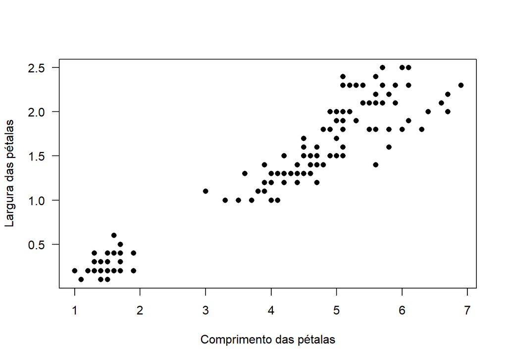

```r
plot(iris$Petal.Length, iris$Petal.Width, las=1, pch=16,
xlab="Comprimento das pétalas", ylab="Largura das pétalas")
```

```r
#se quiser ver todas as possibilidades, chame ?par

#las define a orientação dos números dos eixos x e y

#pch define o tipo de símbolo, veja ?pch para mais detalhes

#xlab e ylab dão nomes aos eixos
```

Agora vamos elaborar mais um pouco, adicionando cores e legenda:

```r
levels(iris$Species)  #Para conferir a ordem das espécies
```

```
## [1] "setosa"     "versicolor" "virginica"
```

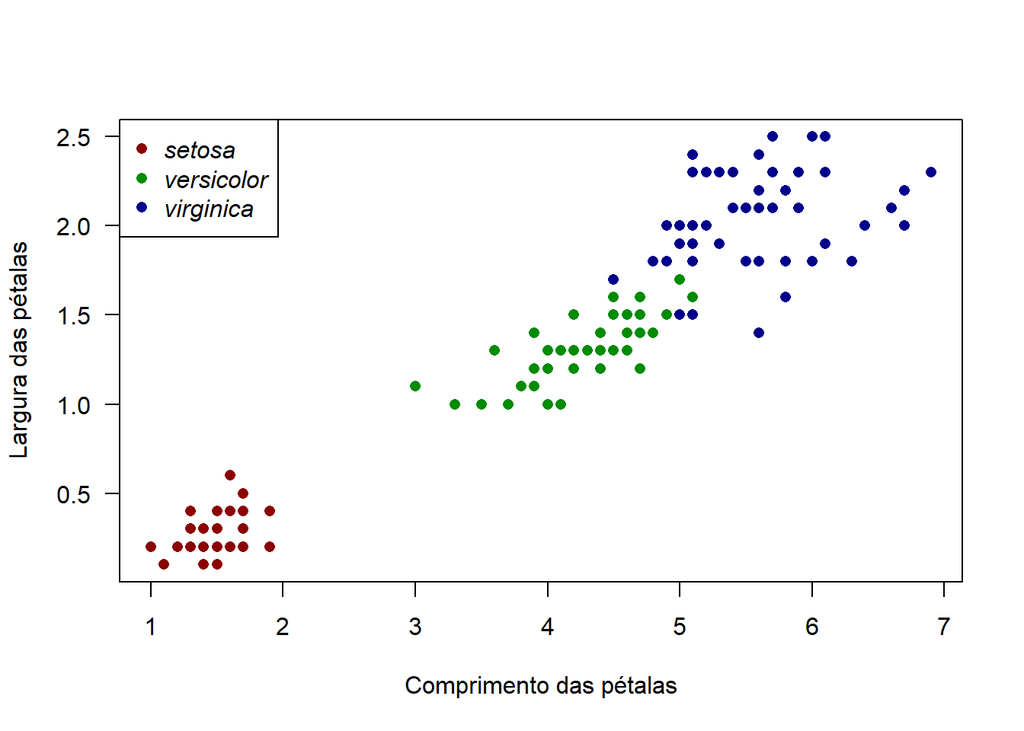

```r
cores<-c("red4", "green4", "blue4")  #Atribuindo uma cor para cada espécie

plot(iris$Petal.Length, iris$Petal.Width, las=1, pch=16,
xlab="Comprimento das pétalas", ylab="Largura das pétalas",
col=cores[iris$Species])

especies<-levels(iris$Species)
legend("topleft", legend=especies, col=cores, pch=16, text.font=3)
```

```r
#"topleft" foi a posição (canto superior esquerdo)

#legend etabeleceu o que foi escrito

#tex.font mudou o tipo de fonte (2 para negrito, 3 para itálico, 4 os dois)
```

E pronto! Avisei que seria um script curto. :D

Um abração, e até o próximo script!

[Prof Marcos](https://medium.com/@marcosvital)

Este documento faz parte do material que disponibilizo no meu blog, o [“Cantinho do R”](http://cantinhodor.wordpress.com/), e foi foi criado utilizando o software R, o programa RStudio e a linguagem Markdown. Para saber mais sobre eles, acesse:

http://www.r-project.org/

http://www.rstudio.com

http://rmarkdown.rstudio.com/

**Quer comentar ou perguntar? Faça isso no blog, [aqui](https://cantinhodor.wordpress.com/arquivo/)**